# Fandango Falsified Ratings Report

Nate Sheibley

2024-09-16

## Introduction

In 2015 Walt Hickey from FiveThirtyEight foudn Fandango was found to artificially inflate the displayed star ratings for movies in a [popular article](https://fivethirtyeight.com/features/fandango-movies-ratings/). The aggregate rating store was accessible in the HTML and displayed a half star lower mode than the displayed rating.

Displayed star ratings were found to round up to the nearest half or whole star in some instances (4.1 -> 4.5 or 5).

This project will review the data from the previous investigation and continue the investigation into 2016 and 2017 to see if the behavior has been corrected, or remains. To do so it will include samples of ‘pre’ and ‘post’ article samples.

## Data Sources

https://github.com/fivethirtyeight/data/blob/master/fandango/README.md https://github.com/mircealex/Movie_ratings_2016_17/blob/master/README.md

### Reading the data

```
## # A tibble: 6 × 5
##   FILM    Fandango_Stars Fandango_Ratingvalue Fandango_votes Fandango_Difference
##   <chr>            <dbl>                <dbl>          <dbl>               <dbl>
## 1 Avenge…            5                    4.5          14846                 0.5
## 2 Cinder…            5                    4.5          12640                 0.5
## 3 Ant-Ma…            5                    4.5          12055                 0.5
## 4 Do You…            5                    4.5           1793                 0.5
## 5 Hot Tu…            3.5                  3             1021                 0.5
## 6 The Wa…            4.5                  4              397                 0.5
```

```r
head(fandango_post)
```

```
## # A tibble: 6 × 3
##   movie                    year fandango
##   <chr>                   <dbl>    <dbl>
## 1 10 Cloverfield Lane      2016      3.5
## 2 13 Hours                 2016      4.5
## 3 A Cure for Wellness      2016      3
## 4 A Dog's Purpose          2017      4.5
## 5 A Hologram for the King  2016      3
## 6 A Monster Calls          2016      4
```

The goal of this project is to determine if the fandango rating system adjusted in the time after Hickey’s analysis. We are interested in all Fandango ratings, regardless of the released year.

Because want to determine if the distribution of the ratings changed over time, pre- and post- the analysis by Hickey, we are sampling the reviews at two points in time, in order to compare the analyses.

The data we are working with was sampled in 2015, the data used by Hickey in his analysis, and 2017, a year or two after the analysis was published. We did not sample close to the analysis being done, so that the site would be able to react and adjust their scoring system if they choose to do so.

We must ensure the sample is representative. From the ReadMe of [repository](https://github.com/fivethirtyeight/data/tree/master/fandango) associated with the Hickey analysis we know the following sampling criteria:

- The movie must have had 30 reviews at the time of Sampling (Aug. 24, 2015)
- The movie must have had tickets on sale in 2015

This sampling is clearly not random, but is representative of popular movies with enough reviews on fandango to have a aggregate rating, and not to be skewed by a few outstanding reviews (negative or positive). It is clearly subject to temporal trends and unlikely to be representative of all movies.

From the ReadMe of the post sample [repository](https://github.com/mircealex/Movie_ratings_2016_17) we also know the sampling of that dataset. It followed the sampling criteria:

- The movie must have been released in 2016 or later.
- The movie must have had a considerable number of votes and reviews (unclear exactly criteria).

This sample also subject to temporal trends and is unlikely to be representative of all movies. However, it may be representative of popular movies that see traffic on fandango.

To confirm the second dataset contains only popular movies, similar to the pre dataset with a minimum of thirty reviews a random sample will be viewed manually.

```r
set.seed(1)
sample_n(fandango_post, size = 10)
```

```
## # A tibble: 10 × 3
##    movie                     year fandango
##    <chr>                    <dbl>    <dbl>
##  1 Hands of Stone            2016      4
##  2 The Bye Bye Man           2017      3
##  3 Our Kind of Traitor       2016      3.5
##  4 The Autopsy of Jane Doe   2016      4.5
##  5 Dirty Grandpa             2016      3.5
##  6 Arsenal                   2017      3.5
##  7 The Light Between Oceans  2016      4
##  8 Exposed                   2016      2.5
##  9 Jason Bourne              2016      4
## 10 Before I Fall             2017      3.5
```

Upon investigation, as of August, 2019 Fandango no longer uses the 5-Star Fan Ratings described above. Instead, Fandango now uses the [Rotten Tomatoes verified Audience Score](https://editorial.rottentomatoes.com/article/introducing-verified-audience-score/). There were many reviews for each movie on rotten tomatoes.

It is possible the rotten tomatoes user base is larger than the fandango user base, so we can not say with certainty that these review numbers are comparable to the 2015 fandango rating numbers. Additionally, it has been many years since the 2017 sample was collected, and many more reviews could have been submitted in the intervening time, so we have no way to verify the review count the 2017 dataset used to filter as ‘popular,’ even if the fandango rating was still in use.

# Isolating the samples of interest

Moving on to the pre dataset, let us confirm the dataset only contains movies that adhere to the sampling criteria.

```r
print(sum(fandango_pre$Fandango_votes < 30))
```

```
## [1] 0
```

```r
print(head(fandango_pre$FILM, n = 10))
```

```
##  [1] "Avengers: Age of Ultron (2015)" "Cinderella (2015)"
##  [3] "Ant-Man (2015)"                 "Do You Believe? (2015)"
##  [5] "Hot Tub Time Machine 2 (2015)"  "The Water Diviner (2015)"
##  [7] "Irrational Man (2015)"          "Top Five (2014)"
##  [9] "Shaun the Sheep Movie (2015)"   "Love & Mercy (2015)"
```

```r
print(fandango_post |> group_by(year) |> summarise(Freq = n()))
```

```
## # A tibble: 2 × 2
##    year  Freq
##   <dbl> <int>
## 1  2016   191
## 2  2017    23
```

The pre- dataset contrains movies from at least 2015 and 2014. The post dataset contains movies from 2016 and 2017. Additionally we can see the year syntax of the movies in the pre dataset and generate a year column.

```r
fandango_pre <- fandango_pre |>
  mutate(year = str_sub(FILM, -5, -2),
         FILM = str_sub(FILM, 0, -8))
fandango_pre |> group_by(year) |> summarise(Freq = n())
```

```
## # A tibble: 2 × 2
##   year   Freq
##   <chr> <int>
## 1 2014     17
## 2 2015    129
```

```r
fdg_2015 <- fandango_pre |>
  filter(year == 2015)

fdg_2016 <- fandango_post |>
  filter(year == 2016)
```

# Comparing the rating distributions of pre- and post- datasets

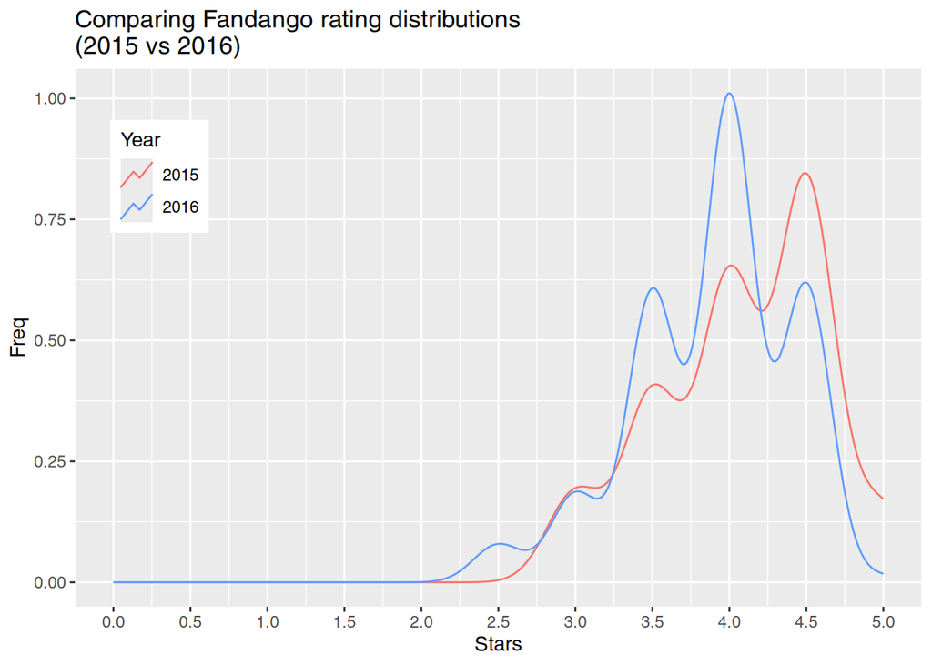

```r
red <- '#F8766D'
blue <- '#619CFF'

legend_colors = c('2015' = red,
                  '2016' = blue)

ggplot() +
  geom_density(data= fdg_2015,
               aes(x=Fandango_Stars,
               color= '2015'),
               key_glyph = "timeseries") +
  geom_density(data= fdg_2016,
               aes(x=fandango,
               color= '2016'),
               key_glyph = "timeseries") +
  labs(title= 'Comparing Fandango rating distributions\n(2015 vs 2016)',
       x='Stars',
       y='Freq') +
  scale_x_continuous(breaks= seq(0,5, by=0.5),
                      limits=c(0,5)) +
  scale_color_manual(name = 'Year',
                     values = legend_colors) +
  theme(legend.position = c(0.1, 0.8),
        key_glyph = "timeseries")
```

```r
names(legend_colors)
```

```
## [1] "2015" "2016"
```

Both distributions are strongly left skewed.

The left shift of the 2016 distribution indicates that ratings shifted during the timeframe we might expect if the Hickey analysis did have an impact.

The fact the left skew remains is fine. This is seen in other rating databases as well.

It appears the number of very high ratings (4.5+) has gone down significantly in the time after the article was published, the 2016 dataset.

```r
fdg_2015 |>
  group_by(Fandango_Stars) |>
  summarise(Percentage = n() / nrow(fdg_2015) * 100)
```

```
## # A tibble: 5 × 2
##   Fandango_Stars Percentage
##            <dbl>      <dbl>
## 1            3         8.53
## 2            3.5      17.8
## 3            4        28.7
## 4            4.5      38.0
## 5            5         6.98
```

```r
fdg_2016 |>
  group_by(fandango) |>
  summarise(Percentage = n() / nrow(fdg_2016) * 100)
```

```
## # A tibble: 6 × 2
##   fandango Percentage
##      <dbl>      <dbl>
## 1      2.5      3.14
## 2      3        7.33
## 3      3.5     24.1
## 4      4       40.3
## 5      4.5     24.6
## 6      5        0.524
```

From these two frequency tables, we can indeed see that the number of very high ratings (4.5+) has gone down significantly from 2015 to 2016. Additionally it is evident that the number of 4.0 below star ratings have increased majorly. To quantify this we will use some summary statistics.

```r
# adapted by DQ from https://stackoverflow.com/questions/2547402/is-there-a-built-in-function-for-finding-the-mode
mode <- function(x) {
  ux <- unique(x)
  ux[which.max(tabulate(match(x, ux)))]
}

stats2015 <- fdg_2015 |> summarise(mean = mean(Fandango_Stars),
                      median = median(Fandango_Stars),
                      mode = mode(Fandango_Stars),
                      stdev = sd(Fandango_Stars),
                      min = min(Fandango_Stars),
                      max = max(Fandango_Stars)) |> t()

stats2016 <-fdg_2016 |> summarise(mean = mean(fandango),
                      median = median(fandango),,
                      mode = mode(fandango),
                      stdev = sd(fandango),
                      min = min(fandango),
                      max = max(fandango)) |> t()

stat <-  c('mean','median', 'mode', 'stdev', 'min', 'max')

summary_stats <- tibble(stat, stats2015, stats2016) |>
  gather(year, value, stats2015:stats2016, factor_key=TRUE)

summary_stats
```

```
## # A tibble: 12 × 3
##    stat   year      value
##    <chr>  <fct>     <dbl>
##  1 mean   stats2015 4.09
##  2 median stats2015 4
##  3 mode   stats2015 4.5
##  4 stdev  stats2015 0.538
##  5 min    stats2015 3
##  6 max    stats2015 5
##  7 mean   stats2016 3.89
##  8 median stats2016 4
##  9 mode   stats2016 4
## 10 stdev  stats2016 0.510
## 11 min    stats2016 2.5
## 12 max    stats2016 5
```

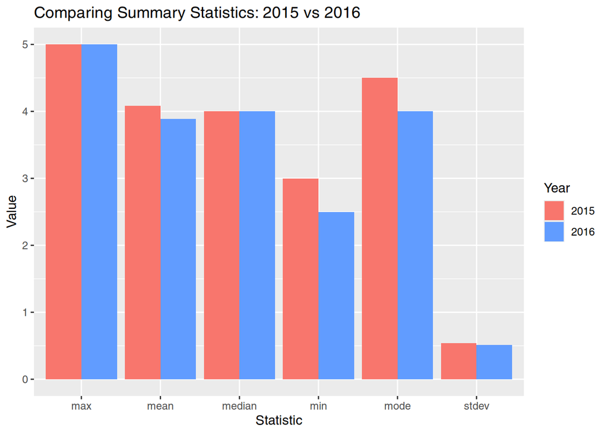

```r
summary_stats |> ggplot(aes(fill=year, x=stat, y=value)) +
  geom_bar(position='dodge', stat = 'identity') +
  labs(title = 'Comparing Summary Statistics: 2015 vs 2016',
       x = 'Statistic',
       y = 'Value',
       fill = 'Year') +
  scale_fill_manual(values = c(red,blue),labels = c('2015', '2016'))
```

# Conclusions

On average the fandango ratings have not decreased much, but the mode and minimum have decreased notably.

at a glance, the star distribution appears to approximate the IMDb scoring distibution from Hickey’s article. It is still a very left skewed distribution but it is no longer as left-skewed, and the mode aligns with other sites.